# Plotting geometries

Author

Jeet Sukumaran

## 1 Setting up the visualization ecosystem

### 1.1 Setting up the environment

We load the environment with the Makie graphical “back-end”, `GLMakie`.

```julia
using GLMakie
```

### 1.2 Creating the `Figure`: the top-level container

We first create an Makie `Figure` object. A `Figure` is the top-level container, in which we are going to compose our picture.

```julia
fig = Figure()
```

### 1.3 Creating the `Axis`: the cooordianate reference system

Here we create an `Axis` object and place it in figure layout position $(1, 1)$, or row 1 and column 1.

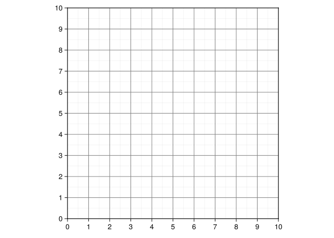

```julia
ax = Axis(
    fig[1, 1];
    aspect = DataAspect(),
    limits = (0, 10, 0, 10),
    xticks = 0:10,
    yticks = 0:10,
    xgridcolor = :grey,
    xminorgridvisible = true,
    ygridcolor = :grey,
    yminorgridvisible = true,
)
fig
```

## 2 Plotting

### 2.1 Coordinates

( Note that Makie assumes *data space* coordinates for its coordinates by default, which is distinct from *pixel space* or screen units. The difference is particularly important when the axes as *anisotropic*: the number of pixels spanned by a data unit in one axis is not the the same as the other. For example, 1 coordinate or data space unit on the $x$-axis may correspond to 20 pixels while one unit on the y-axis may correspond to 40 pixels.1 The `aspect = DataAspect()` argument to the `Axis` constructor forces both axes to assume the same number of pixels for a single data space coordinate unit. )

### 2.2 The fundamental geometries

#### 2.2.1 Points

We use the `scatter!` function to plot points onto an axis.

**TipMutating vs. non-mutating functions**

In Julia, by conventions, functions that mutate (change the value or state) of any arguments passed to them have a “`!`” (exclamation point, often called a “bang operator” in programming contexts), while variants that do not are undecorated. Here we are plotting onto an existing axis, and the function we use has the `!` in its name reflecting its has “side-effects”: `scatter!(ax, ...)`. There is variant without the “`!`” in its name, `scatter(...)`, that does not mutate any of its arguments by creating and returning its own `FigureAxisPlot` object instead of changing the state of one provided.

The `scatter!` function plots point geometries on an `Axis` object. It takes the `Axis` object and point coordinates as the positional arguments.

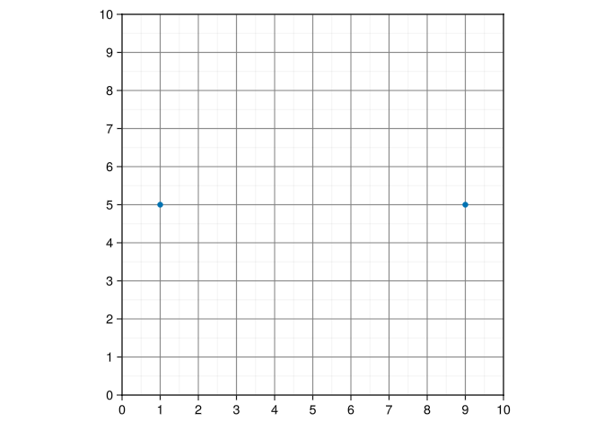

```julia
scatter!(
    ax, [
        (1.0, 5.0),
        (9.0, 5.0),
    ]
)
fig
```

A suite of keyword arguments control various aspects of the aesthetics such as [marker](https://docs.makie.org/dev/reference/plots/scatter), size, [color](https://juliagraphics.github.io/Colors.jl/stable/namedcolors/), etc.

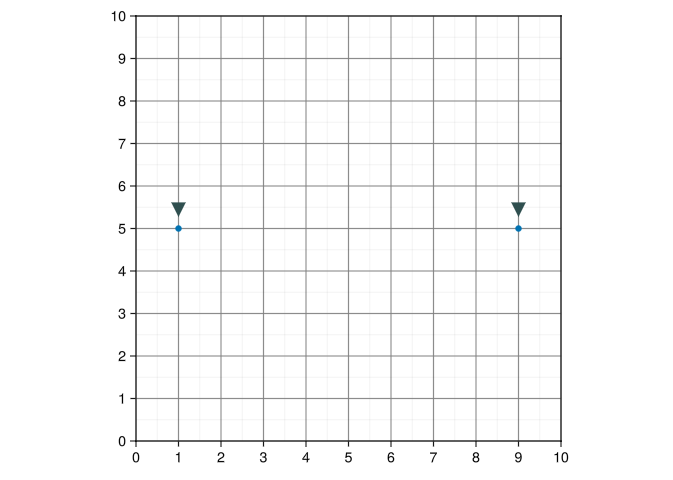

```julia
scatter!(
    ax, [
        (1.0, 5.5),
        (9.0, 5.5),
    ];
    marker = :dtriangle,
    markersize = 20,
    color = :darkslategrey,
)
fig
```

#### 2.2.2 Lines

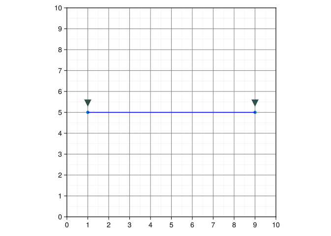

```julia
lines!(
    ax, [
        (1, 5),
        (9, 5),
    ];
    color = :blue,
)
fig
```

#### 2.2.3 Polygons

The `poly!` function draws filled polygonal regions onto an `Axis`. Vertices are given as a list of coordinate tuples, traced in order around the perimeter; `poly!` automatically closes the shape back to the first point.

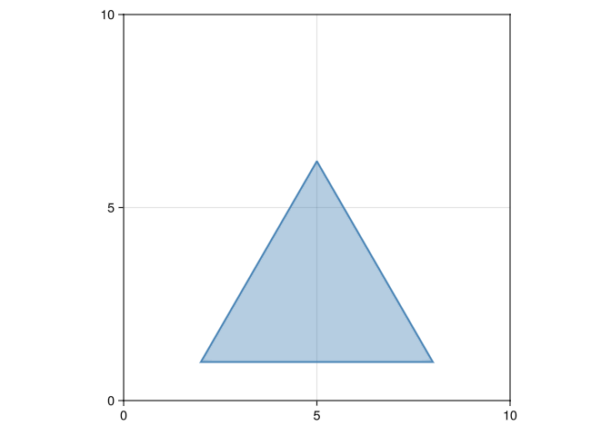

```julia
fig = Figure()
ax = Axis(fig[1, 1]; aspect = DataAspect(), limits = (0, 10, 0, 10))

# An equilateral triangle (Euclid def. 20: "having three equal sides")
poly!(
    ax,
    [(2.0, 1.0), (5.0, 6.2), (8.0, 1.0)];
    color = (:steelblue, 0.4),
    strokecolor = :steelblue,
    strokewidth = 2,
)
fig
```

We can layer multiple polygons onto the same axis. Here we add a quadrilateral (Euclid def. 22).

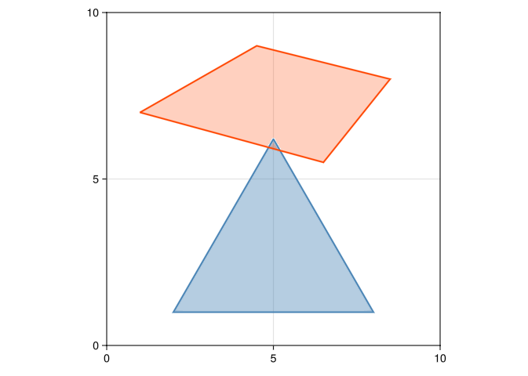

```julia
poly!(
    ax,
    [(1.0, 7.0), (4.5, 9.0), (8.5, 8.0), (6.5, 5.5)];
    color = (:orangered, 0.25),
    strokecolor = :orangered,
    strokewidth = 2,
)
fig
```

**Tip`poly!` accepts many geometry types**

Beyond a plain list of vertex coordinates, `poly!` also accepts `GeometryBasics.Polygon` (which supports interior holes), `Rect`, `Circle`, and `BezierPath` — anything that describes a closed, filled region.

#### 2.2.4 Bezier curves

Makie’s `BezierPath` represents a path as a sequence of drawing commands. `poly!` fills the enclosed region; `lines!` traces the path itself, unfilled. The principal commands are:

| Command | Action |
| --- | --- |
| `MoveTo(x, y)` | Start a new subpath at $(x, y)$ |
| `LineTo(x, y)` | Straight line to $(x, y)$ |
| `CurveTo(c1x, c1y, c2x, c2y, x, y)` | Cubic Bézier arc to $(x, y)$, shaped by control points $(c1x, c1y)$ and $(c2x, c2y)$ |
| `EllipticalArc(cx, cy, rx, ry, rot, a1, a2)` | Arc of an ellipse centered at $(cx, cy)$ |
| `ClosePath()` | Straight line back to the most recent `MoveTo` |

A cubic Bézier arc is defined by 2 endpoints and 2 *control points*. The curve passes through its endpoints but is only *pulled toward* the control points — it never reaches them:

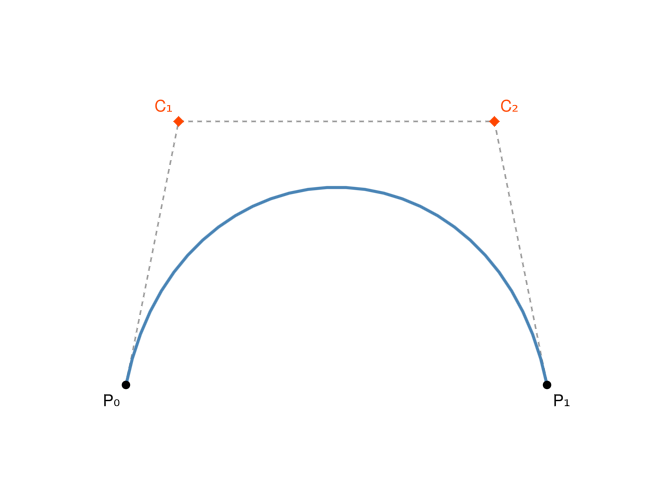

The dashed frame is the *control polygon*: the 4 points $P_0 \to C_1 \to C_2 \to P_1$, connected in order. Dragging a control point ($C_1$ or $C_2$) reshapes the arc toward it; dragging an endpoint ($P_0$ or $P_1$) moves where the arc starts or ends.

Building the same curve with `BezierPath` takes only a `MoveTo` for the first endpoint and a `CurveTo` for the arc:

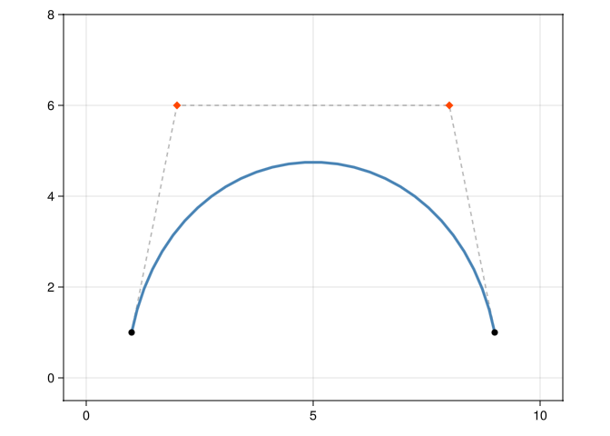

```julia
fig = Figure()
ax = Axis(fig[1, 1]; aspect = DataAspect(), limits = (-0.5, 10.5, -0.5, 8.0))

p0 = (1.0, 1.0)
c1 = (2.0, 6.0)
c2 = (8.0, 6.0)
p1 = (9.0, 1.0)

arch_curve = BezierPath([
    MoveTo(p0...),
    CurveTo(c1..., c2..., p1...),
])

# Control polygon: P0 -> C1 -> C2 -> P1, connected in order
lines!(ax, [p0, c1, c2, p1]; color = (:grey, 0.6), linestyle = :dash, linewidth = 1.5)
lines!(ax, arch_curve; color = :steelblue, linewidth = 3)
scatter!(ax, [p0, p1]; color = :black, markersize = 10)
scatter!(ax, [c1, c2]; marker = :diamond, color = :orangered, markersize = 10)
fig
```

`lines!` accepts a `BezierPath` directly and traces it without filling — useful whenever the curve itself, not an enclosed area, is what needs to be drawn.

**Tip`lines!` vs. `linesegments!`**

`lines!` connects consecutive points into 1 continuous polyline, which is what a control polygon needs. `linesegments!` instead treats its input as independent pairs, drawing a separate segment for every 2 points — useful for unconnected marks such as error bars, not for a connected frame like this one.

In practice, Bezier curves are most often used to build closed, filled shapes rather than bare arcs. A second `CurveTo` can close a path back to its start, producing a symmetric petal:

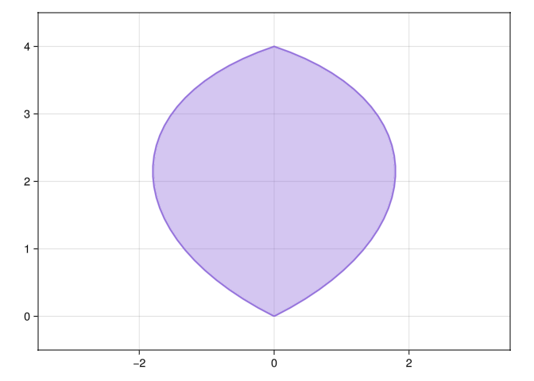

```julia
fig = Figure()
ax = Axis(fig[1, 1]; aspect = DataAspect(), limits = (-3.5, 3.5, -0.5, 4.5))

petal = BezierPath([
    MoveTo(0.0, 0.0),
    CurveTo(-2.4, 1.2, -2.4, 3.2, 0.0, 4.0),
    CurveTo(2.4, 3.2, 2.4, 1.2, 0.0, 0.0),
    ClosePath(),
])

poly!(
    ax,
    petal;
    color = (:mediumpurple, 0.4),
    strokecolor = :mediumpurple,
    strokewidth = 2,
)
fig
```

Each `CurveTo` shapes 1 side of the petal; the 2 arcs meet at the shared points $(0, 0)$ and $(0, 4)$. This is the same technique behind the custom scatter markers in the next tip: build a closed `BezierPath`, then hand it to `poly!` for a standalone shape, or to `scatter!` as a marker.

**Tip`BezierPath` as a scatter marker**

`BezierPath` objects can also be passed as the `marker` keyword argument to `scatter!`, making any custom shape usable as a point marker. Makie provides several named polygon markers out of the box:

```julia
scatter!(ax, pts; marker = :pentagon, markersize = 30)
scatter!(ax, pts; marker = :hexagon,  markersize = 30)
scatter!(ax, pts; marker = :octagon,  markersize = 30)
```

For a fully custom shape, construct and pass a `BezierPath` directly:

```julia
heart = BezierPath("M 0,-0.5 C 0.5,-1 1,0 0,0.5 C -1,0 -0.5,-1 0,-0.5 z",
                   fit = true)
scatter!(ax, pts; marker = heart, markersize = 30)
```

### 2.3 Colors

Back to top